# Community detection

Pablo Barbera

#### Importing network data into R

In this training session we will be using a small dataset to illustrate how to identify latent communities in networks. The dataset corresponds to the Twitter ego network of POIR – each node is another Twitter account that the USC POIR account follows, and the edges indicate whether each of those accounts in turn follow each other. (See at the end of this script for the code on how I put together this network.) Edges are thus directed.

The first step is to read the list of edges and nodes in this network:

```r
edges <- read.csv("../data/poir-edges.csv", stringsAsFactors=FALSE)
head(edges)
```

```
##      Source     Target
## 1 102803242  114865774
## 2 102803242 1170012108
## 3 102803242  122517396
## 4 102803242 1265031758
## 5 102803242  135959346
## 6 102803242   15780295
```

```r
nodes <- read.csv("../data/poir-nodes.csv", stringsAsFactors=FALSE)
head(nodes)
```

```
##             Id           Label                 name
## 1 1.028032e+08 USCCareerCenter    USC Career Center
## 2 1.032744e+18 Dr_Wanda_Austin         Wanda Austin
## 3 1.059724e+09    JoeySaraceno        Joey Saraceno
## 4 1.091604e+18 EdwardG74882741      Edward Gonzalez
## 5 1.110664e+18   PresidentFolt           Carol Folt
## 6 1.124483e+08          BJPolS British Jnl Poli Sci
##                                                                                                                                                description
## 1                                                                          Providing exceptional career services to all members of the #USC Trojan Family.
## 2                         Archive of tweets from Dr. Wanda M. Austin, sent during her time as Interim President of @USC. This account is no longer active.
## 3                                                                                        @USC PhD Candidate l @UCLA Alum '16 | he/him \U0001f3f3️‍\U0001f308
## 4 USC POIR PhD Candidate. Student of political philosophy, comparative politics, and international relations. Future professor of international relations.
## 5                                                                                                       President of the University of Southern California
## 6                                                                                    British Journal of Political Science from Cambridge University Press.
##   followers_count statuses_count friends_count                     created_at
## 1            8998           8238          1240 Thu Jan 07 22:00:57 +0000 2010
## 2            1161            225            92 Thu Aug 23 21:40:06 +0000 2018
## 3             220            589           233 Fri Jan 04 06:40:15 +0000 2013
## 4             120            757           171 Sat Feb 02 07:47:02 +0000 2019
## 5            9732           1155           121 Tue Mar 26 22:03:10 +0000 2019
## 6           17267           6633          1357 Mon Feb 08 14:52:14 +0000 2010
##          location
## 1 Los Angeles, CA
## 2 Los Angeles, CA
## 3 Los Angeles, CA
## 4 California, USA
## 5 Los Angeles, CA
## 6       Cambridge
```

Now, how do we create the igraph object? We can use the `graph_from_data_frame` function, which takes two arguments: `d`, the data frame with the edge list in the first two columns; and `vertices`, a data frame with node data with the node label in the first column. (Note that igraph calls the nodes `vertices`, but it’s exactly the same thing.)

```r
library(igraph)
g <- graph_from_data_frame(d=edges, vertices=nodes, directed=FALSE)
g
```

```
## IGRAPH 58cdc2e UN-- 221 2067 --
## + attr: name (v/c), Label (v/c), description (v/c), followers_count
## | (v/n), statuses_count (v/n), friends_count (v/n), created_at (v/c),
## | location (v/c)
## + edges from 58cdc2e (vertex names):
##  [1] USC Career Center--USC Gould Law
##  [2] USC Career Center--CESR
##  [3] USC Career Center--USC Dornsife
##  [4] USC Career Center--USC Sociology
##  [5] USC Career Center--USC Alumni Association
##  [6] USC Career Center--USC Research
## + ... omitted several edges
```

What does it mean? - `U` means undirected  
- `N` means named graph  
- `221` is the number of nodes  
- `2067` is the number of edges  
- `name (v/c)` means *name* is a node attribute and it’s a character

#### Network communities

Networks often have different clusters or communities of nodes that are more densely connected to each other than to the rest of the network. Let’s cover some of the different existing methods to identify these communities.

The most straightforward way to partition a network is into **connected components**. Each component is a group of nodes that are connected to each other, but *not* to the rest of the nodes. For example, this network has 108 components, with the largest one (often called giant component - see more below) containing 114 nodes.

```r
comp <- components(g)
comp$no # number of components
```

```
## [1] 108
```

```r
max(comp$csize) # size of largest component
```

```
## [1] 114
```

Most networks have a single **giant connected component** that includes most nodes. Most studies of networks actually focus on the giant component, which is what we will do here. One important reason is due to feasibility: e.g. the shortest path between nodes in a network with two or more component is Inf!.

```r
giant <- decompose(g, mode="strong")[[1]]
giant
```

```
## IGRAPH 2a16c8e UN-- 114 2067 --
## + attr: name (v/c), Label (v/c), description (v/c), followers_count
## | (v/n), statuses_count (v/n), friends_count (v/n), created_at (v/c),
## | location (v/c)
## + edges from 2a16c8e (vertex names):
##  [1] USC Career Center--USC Gould Law
##  [2] USC Career Center--CESR
##  [3] USC Career Center--USC Dornsife
##  [4] USC Career Center--USC Sociology
##  [5] USC Career Center--USC Alumni Association
##  [6] USC Career Center--USC Research
## + ... omitted several edges
```

Components can be **weakly connected** (in undirected networks) or **strongly connected** (in directed networks, where there is an edge that ends in every single node of that component).

```r
weakly <- decompose(g, mode="weak")[[1]]
weakly
```

```
## IGRAPH 796bbb7 UN-- 114 2067 --
## + attr: name (v/c), Label (v/c), description (v/c), followers_count
## | (v/n), statuses_count (v/n), friends_count (v/n), created_at (v/c),
## | location (v/c)
## + edges from 796bbb7 (vertex names):
##  [1] USC Career Center--USC Gould Law
##  [2] USC Career Center--CESR
##  [3] USC Career Center--USC Dornsife
##  [4] USC Career Center--USC Sociology
##  [5] USC Career Center--USC Alumni Association
##  [6] USC Career Center--USC Research
## + ... omitted several edges
```

And now we keep only the giant component:

```r
g <- decompose(g, mode="strong")[[1]]
nodes <- nodes[nodes$Label %in% V(g)$Label,]
```

Even within a giant component, there can be different subsets of the network that are more connected to each other than to the rest of the network. The goal of **community detection algorithms** is to identify these subsets.

There are a few different algorithms, each following a different logic.

The **walktrap** algorithm finds communities through a series of short random walks. The idea is that these random walks tend to stay within the same community. The length of these random walks is 4 edges by default, but you may want to experiment with different values (longer random walks will lead to fewer communities). The goal of this algorithm is to identify the partition that maximizes a modularity score.

```r
cluster_walktrap(g) # default is 4 steps
```

```
## IGRAPH clustering walktrap, groups: 5, mod: 0.4
## + groups:
##   $`1`
##    [1] "British Jnl Poli Sci"
##    [2] "Raquel Centeno"
##    [3] "The Monkey Cage (TMC)"
##    [4] "Dave Ebner, Ph.D."
##    [5] "Euro Pol Sci Review"
##    [6] "International Theory"
##    [7] "Wayne Sandholtz"
##    [8] "Therese Anders"
##    [9] "Morris Levy"
##   + ... omitted several groups/vertices
```

```r
cluster_walktrap(g, steps=2)
```

```
## IGRAPH clustering walktrap, groups: 8, mod: 0.4
## + groups:
##   $`1`
##    [1] "Raquel Centeno"
##    [2] "The Monkey Cage (TMC)"
##    [3] "Dave Ebner, Ph.D."
##    [4] "Wayne Sandholtz"
##    [5] "Therese Anders"
##    [6] "Morris Levy"
##    [7] "Nico Napolio"
##    [8] "Suzie Mulesky"
##    [9] "Hank Scorpio, CEO"
##   + ... omitted several groups/vertices
```

```r
cluster_walktrap(g, steps=5)
```

```
## IGRAPH clustering walktrap, groups: 3, mod: 0.39
## + groups:
##   $`1`
##    [1] "USC Career Center"
##    [2] "Wanda Austin"
##    [3] "USC Gould Law"
##    [4] "CESR"
##    [5] "USC Global Policy Institute"
##    [6] "USC Dornsife"
##    [7] "USC Sociology"
##    [8] "USC Alumni Association"
##    [9] "Dr. Jay Maharjan"
##   + ... omitted several groups/vertices
```

```r
cluster_walktrap(g, steps=10)
```

```
## IGRAPH clustering walktrap, groups: 2, mod: 0.39
## + groups:
##   $`1`
##    [1] "USC Career Center"
##    [2] "Wanda Austin"
##    [3] "USC Gould Law"
##    [4] "CESR"
##    [5] "USC Global Policy Institute"
##    [6] "USC Dornsife"
##    [7] "USC Sociology"
##    [8] "USC Alumni Association"
##    [9] "Dr. Jay Maharjan"
##   + ... omitted several groups/vertices
```

Other methods are:

- The **infomap** method attempts to map the flow of information in a network, and the different clusters in which information may get remain for longer periods. Similar to walktrap, but not necessarily maximizing modularity, but rather the so-called “map equation”.
- The **edge-betweenness** method iteratively removes edges with high betweenness, with the idea that they are likely to connect different parts of the network. Here betweenness (gatekeeping potential) applies to edges, but the intuition is the same.
- The **label propagation** method labels each node with unique labels, and then updates these labels by choosing the label assigned to the majority of their neighbors, and repeat this iteratively until each node has the most common labels among its neighbors.
- The **Louvain algorithm** initially assigns each node to its own community; nodes are then sequentially assigned to the community that increases modularity (if any) so that communities are merged; this merging process continues until modularity cannot increase or only one community remains.

```r
cluster_infomap(g)
cluster_edge_betweenness(g)
cluster_label_prop(g)
cluster_louvain(g)
```

The choice of one or other algorithm may depend on substantive or practical reasons, as always. For now, let’s pick the Louvain algorithm, which identifies three clusters.

```r
comm <- cluster_louvain(g)
nodes$cluster <- membership(comm)
```

Who’s in each cluster?

```r
head(nodes$Label[nodes$cluster==1], n=10)
```

```
##  [1] "USCCareerCenter" "Dr_Wanda_Austin" "USCGouldLaw"     "CESRUSC"
##  [5] "uscgpi"          "USCDornsife"     "USCSociology"    "USCAlumni"
##  [9] "4entrepreneur"   "USC_Research"
```

```r
head(nodes$Label[nodes$cluster==2], n=10)
```

```
##  [1] "BJPolS"          "RaqCenteno"      "monkeycageblog"  "shallow__state"
##  [5] "EPSRjournal"     "InternatlTheory" "WayneSandholtz"  "thereanders"
##  [9] "MorrisLevy8"     "europsa"
```

```r
head(nodes$Label[nodes$cluster==3], n=10)
```

```
##  [1] "USATODAY"        "NCSLorg"         "maristpoll"      "JerryBrownGov"
##  [5] "SenatorTimScott" "FiveThirtyEight" "washingtonpost"  "KNBC4Desk"
##  [9] "CAgovernor"      "LegalAidLA"
```

An even better way to understand the content of each cluster is to combine what we’ve learnt about text analysis so far. Let’s see what that reveals:

```r
library(quanteda)
library(quanteda.textstats)

# most frequent features
for (i in 1:3){
  message("Cluster ", i)
  dfm <- dfm(tokens(nodes$description[nodes$cluster==i],
             remove_punct=TRUE)) %>%
    dfm_remove(stopwords("english"))
  print(topfeatures(dfm, n=25))
}
```

```
## Cluster 1
```

```
##          usc   university     southern     official   california      account
##           23           13           12           11            8            7
##      twitter       school         @usc     research           us       alumni
##            7            6            5            5            5            5
##            |     students       follow     dornsife   department      studies
##            5            4            4            4            4            4
##       center california's       office         news       career         #usc
##            4            4            4            4            3            3
##       trojan
##            3
```

```
## Cluster 2
```

```
##                    |            political              science
##                   45                   32                   22
##             politics             @uscpoir                  phd
##                   16                   12                   12
##        international            scientist          association
##                   10                    9                    9
##                 prof              journal               social
##                    8                    7                    7
##            candidate \U0001f3f3‍\U0001f308            assistant
##                    7                    6                    6
##                 ph.d                 @usc                  usc
##                    6                    6                    6
##           university               public            relations
##                    5                    5                    5
##                  law            professor                 race
##                    5                    4                    4
##                 data
##                    4
```

```
## Cluster 3
```

```
##      opinion         news       nation     official     national        state
##            3            3            2            2            2            2
##         home         poll       public       across     governor   california
##            2            2            2            2            2            2
##        chair       living     analysis      account       office        pulse
##            2            2            2            2            2            1
##         palm         hand      twitter         page   conference legislatures
##            1            1            1            1            1            1
##   bipartisan
##            1
```

```r
# most distinctive features
poir <- dfm(tokens(corpus(nodes[,c("description", "cluster")], text_field="description")))
for (i in 1:3){
    print(
      head(textstat_keyness(poir, target=docvars(poir)$cluster==i,
                      measure="lr"), n=20)
    )
}
```

```
##       feature        G2            p n_target n_reference
## 1         usc 18.053584 0.0000214774       23           6
## 2    southern 12.125742 0.0004973054       12           2
## 3           ! 10.212601 0.0013948433        8           0
## 4          of  9.198927 0.0024215699       46          34
## 5  university  7.271034 0.0070075451       13           5
## 6      school  6.923854 0.0085053476        6           0
## 7    official  6.503901 0.0107638096       11           4
## 8         the  5.639173 0.0175634871       45          39
## 9     twitter  5.486006 0.0191692854        7           1
## 10        for  5.364568 0.0205498836       17          10
## 11     alumni  5.323275 0.0210424324        5           0
## 12        our  5.323275 0.0210424324        5           0
## 13         we  4.140953 0.0418575930        6           1
## 14     center  3.769432 0.0521973621        4           0
```

[output cut: 48 more lines]

```r
# location
poir <- dfm(tokens(corpus(nodes[,c("location", "cluster")], text_field="location")))
for (i in 1:3){
    print(
      head(textstat_keyness(poir, target=docvars(poir)$cluster==i,
                      measure="lr"), n=20)
    )
}
```

```
##          feature           G2            p n_target n_reference
## 1        angeles 12.037208461 0.0005214901       35          15
## 2            los 12.037208461 0.0005214901       35          15
## 3             ca  2.291526429 0.1300819367       23          16
## 4            usc  1.668091001 0.1965144243        3           0
## 5     california  0.018831826 0.8908497097        4           4
## 6              &  0.002305024 0.9617077434        1           0
## 7              -  0.002305024 0.9617077434        1           0
## 8              /  0.002305024 0.9617077434        1           0
## 9            241  0.002305024 0.9617077434        1           0
## 10           314  0.002305024 0.9617077434        1           0
## 11        alumni  0.002305024 0.9617077434        1           0
## 12           arm  0.002305024 0.9617077434        1           0
## 13       bologna  0.002305024 0.9617077434        1           0
## 14 ca-washington  0.002305024 0.9617077434        1           0
```

[output cut: 48 more lines]

The final way in which we can think about network communities is in terms of hierarchy or structure. We’ll discuss one of these methods.

**K-core decomposition** allows us to identify the core and the periphery of the network. A k-core is a maximal subnet of a network such that all nodes have at least degree K.

```r
str(coreness(g))
```

```
##  Named num [1:114] 32 29 22 32 27 24 32 27 15 15 ...
##  - attr(*, "names")= chr [1:114] "USC Career Center" "Wanda Austin" "British Jnl Poli Sci" "USC Gould Law" ...
```

```r
head(which(coreness(g)==32), n=10) # what is the core of the network?
```

```
##      USC Career Center          USC Gould Law                   CESR
##                      1                      4                      7
##           USC Dornsife          USC Sociology USC Alumni Association
##                     12                     13                     18
##           USC Research               USC EASC                    USC
##                     22                     31                     34
##          USC Admission
##                     35
```

```r
head(which(coreness(g)==1), n=10) # what is the periphery of the network?
```

```
## Quinnipiac University Poll
##                         97
```

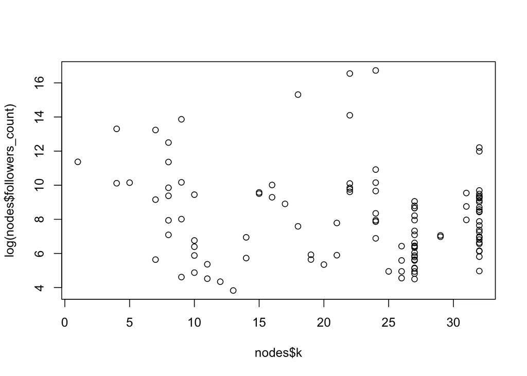

```r
# looking at what predicts being in the core
nodes$k <- coreness(g)
# number of followers?
plot(nodes$k, log(nodes$followers_count))
```

```r
cor(nodes$k, log(nodes$followers_count))
```

```
## [1] -0.167775
```

```r
# text?
poir <- dfm(tokens(corpus(nodes[,c("description", "k")], text_field="description")))
head(textstat_keyness(poir, target=docvars(poir)$k>=30,
                      measure="lr"), n=20)
```

```
##        feature        G2            p n_target n_reference
## 1          usc 12.282516 0.0004572216       17          12
## 2       alumni  8.651456 0.0032680008        5           0
## 3          our  8.651456 0.0032680008        5           0
## 4          the  6.619370 0.0100875531       34          50
## 5       center  6.311210 0.0119976925        4           0
## 6          you  6.311210 0.0119976925        4           0
## 7       school  5.799080 0.0160345603        5           1
## 8     southern  4.168346 0.0411859899        8           6
## 9     #fighton  4.047390 0.0442396846        3           0
## 10        #usc  4.047390 0.0442396846        3           0
## 11 development  4.047390 0.0442396846        3           0
## 12         rts  4.047390 0.0442396846        3           0
## 13           :  3.729574 0.0534570246        7           5
## 14  university  3.119067 0.0773810869        9           9
## 15         and  3.011206 0.0826907263       25          42
## 16           !  2.872709 0.0900931243        5           3
## 17    research  2.872709 0.0900931243        5           3
## 18     twitter  2.872709 0.0900931243        5           3
## 19         for  2.153552 0.1422405053       11          16
## 20          of  2.113089 0.1460443003       28          52
```

```r
head(textstat_keyness(poir, target=docvars(poir)$k<30,
                      measure="lr"), n=20)
```

```
##          feature        G2            p n_target n_reference
## 1      political 21.582523 3.389261e-06       33           0
## 2              | 15.745460 7.246165e-05       47           3
## 3        science  8.670133 3.234676e-03       22           1
## 4       @uscpoir  4.601523 3.194357e-02       12           0
## 5  international  4.601523 3.194357e-02       12           0
## 6            phd  4.601523 3.194357e-02       12           0
## 7    association  3.485100 6.192360e-02       10           0
## 8       politics  3.396124 6.534982e-02       17           2
## 9              (  2.942327 8.628635e-02        9           0
## 10             )  2.942327 8.628635e-02        9           0
## 11          from  2.942327 8.628635e-02        9           0
## 12     scientist  2.942327 8.628635e-02        9           0
## 13             ,  2.589268 1.075900e-01       92          25
## 14          prof  2.413049 1.203278e-01        8           0
## 15             '  1.900916 1.679758e-01        7           0
## 16     assistant  1.900916 1.679758e-01        7           0
## 17     candidate  1.900916 1.679758e-01        7           0
## 18             i  1.900916 1.679758e-01        7           0
## 19       journal  1.900916 1.679758e-01        7           0
## 20        public  1.900916 1.679758e-01        7           0
```

If you want to learn more about this technique, see our [paper in PLOS ONE](http://journals.plos.org/plosone/article?id=10.1371/journal.pone.0143611) where we use it to study large-scale Twitter networks in the context of protest events.

In case you’re curious, here’s the code I used to collect the data:

```r
library(tweetscores)
options(stringsAsFactors=F)
oauth_folder = "~/Dropbox/credentials/twitter/"

accounts <- getFriends("uscpoir", oauth=oauth_folder)

# creating folders (if they do not exists)
try(dir.create("../data/friends"))

# first check if there's any list of friends already downloaded to 'outfolder'
accounts.done <- gsub(".rdata", "", list.files("../data/friends"))
accounts.left <- accounts[accounts %in% accounts.done == FALSE]
accounts.left <- accounts.left[!is.na(accounts.left)]

# loop over the rest of accounts, downloading friend lists from API
while (length(accounts.left) > 0){

    # sample randomly one account to get friends
    new.user <- sample(accounts.left, 1)
    #new.user <- accounts.left[1]
    cat(new.user, "---", length(accounts.left), " accounts left!\n")

    # download followers (with some exception handling...)
    error <- tryCatch(friends <- getFriends(user_id=new.user,
        oauth=oauth_folder, sleep=0.5, verbose=FALSE), error=function(e) e)
    if (inherits(error, 'error')) {
        cat("Error! On to the next one...")
        accounts.left <- accounts.left[-which(accounts.left %in% new.user)]
        next
    }

    # save to file and remove from lists of "accounts.left"
    file.name <- paste0("../data/friends/", new.user, ".rdata")
    save(friends, file=file.name)
    accounts.left <- accounts.left[-which(accounts.left %in% new.user)]

}

# keeping only those that we were able to download
accounts <- gsub(".rdata", "", list.files("../data/friends"))

# reading and creating network
edges <- list()
for (i in 1:length(accounts)){
    file.name <- paste0("../data/friends/", accounts[i], ".rdata")
    load(file.name)
    if (length(friends)==0){ next }
    chosen <- accounts[accounts %in% friends]
    if (length(chosen)==0){ next }
    edges[[i]] <- data.frame(
        source = accounts[i], target = chosen)
}

edges <- do.call(rbind, edges)
nodes <- data.frame(id_str=unique(c(edges$source, edges$target)))

# adding user data
users <- getUsersBatch(ids=nodes$id_str, oauth=oauth_folder)
nodes <- merge(nodes, users)

library(igraph)
g <- graph_from_data_frame(d=edges, vertices=nodes, directed=TRUE)
g

names(nodes)[1:2] <- c("Id", "Label")
names(edges)[1:2] <- c("Source", "Target")
write.csv(nodes, file="../data/poir-nodes.csv", row.names=FALSE)
write.csv(edges, file="../datapoir-edges.csv", row.names=FALSE)
```